# **Cardio Good Fitness Project - Linear Regression Analysis Of A Retail Store That Sells Treadmill Products - By David Salako.**

#### **Product vs. Miles.**

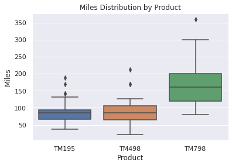

```python
# BIVARIATE ANALYSIS
# Let us compare Product and Miles in a boxplot display

sns.boxplot(x="Product", y="Miles", data=CGFPdf).set_title('Miles Distribution by Product');
```

#### **Product vs. Miles Per Usage.**

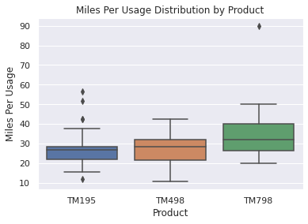

```python
# Let us compare Product and Miles Per Usage in a boxplot display

sns.boxplot(x="Product", y="Miles Per Usage", data=CGFPdf).set_title('Miles Per Usage Distribution by Product');
```

OBSERVATIONS ABOVE:

- Analysis focused on the miles per usage per customer, TM798 customers expect to run more miles each time they run on the treadmill with a range of approximately 19 miles to 49 miles. They are more ambitious and driven than the buyers of the other 2 treadmill models.

#### **Product vs. Gender.**

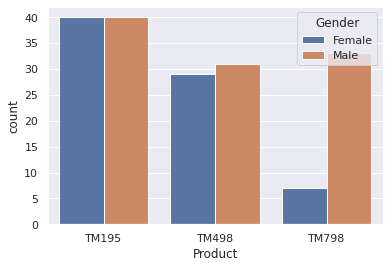

```python
# BIVARIATE ANALYSIS
# Product Buyers by Gender
sns.countplot(x="Product", hue="Gender", data=CGFPdf);
```

OBSERVATIONS ABOVE:

- TM798 has been bought more by the male customers as compared to the female customers, for TM195 and TM498 there is equal distribution among genders.
- Treadmill purchases are more popular overall among males compared to females.
- The TM195 treadmill model is an almost even split between genders, so is TM498.
- Quite noticeably, there is a a preference for the TM798 treadmill model among males.

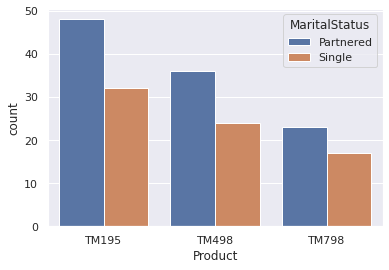

```python
# Product Buyers by Marital Status
sns.countplot(x="Product", hue="MaritalStatus", data=CGFPdf);
```

OBSERVATIONS ABOVE:

- All the products are couple/partner friendly.
- Couples/partnered customers have a higher chance of buying a product when compared to single customers.
- More partnered customers (107) purchased treadmills compared to self declared single cusotomers (73) across all 3 treadmill model types.

#### **Pairplot Visualization.**

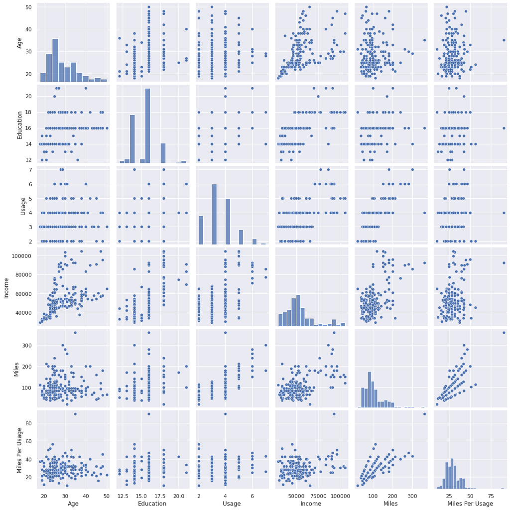

```python
# A pairplot visulaization represents pairwise relation across the entire dataframe and supports
# an additional argument called hue for categorical separation.
# It creates a jointplot between every possible numerical column.

sns.pairplot(CGFPdf);
```

### Building Customer Profiles by Grouping the Data along Product Lines.

```python
CGFPdf[CGFPdf["Product"]=="TM195"].describe(include="all")
```

|  | Product | Age | Gender | Education | MaritalStatus | Usage | Fitness | Income | Miles | Miles Per Usage |
| --- | --- | --- | --- | --- | --- | --- | --- | --- | --- | --- |
| count | 80 | 80.000000 | 80 | 80.000000 | 80 | 80.000000 | 80.0 | 80.00000 | 80.000000 | 80.000000 |
| unique | 1 | NaN | 2 | NaN | 2 | NaN | 5.0 | NaN | NaN | NaN |
| top | TM195 | NaN | Male | NaN | Partnered | NaN | 3.0 | NaN | NaN | NaN |
| freq | 80 | NaN | 40 | NaN | 48 | NaN | 54.0 | NaN | NaN | NaN |
| mean | NaN | 28.550000 | NaN | 15.037500 | NaN | 3.087500 | NaN | 46418.02500 | 82.787500 | 27.113125 |
| std | NaN | 7.221452 | NaN | 1.216383 | NaN | 0.782624 | NaN | 9075.78319 | 28.874102 | 7.559590 |
| min | NaN | 18.000000 | NaN | 12.000000 | NaN | 2.000000 | NaN | 29562.00000 | 38.000000 | 11.750000 |
| 25% | NaN | 23.000000 | NaN | 14.000000 | NaN | 3.000000 | NaN | 38658.00000 | 66.000000 | 22.000000 |
| 50% | NaN | 26.000000 | NaN | 16.000000 | NaN | 3.000000 | NaN | 46617.00000 | 85.000000 | 26.875000 |
| 75% | NaN | 33.000000 | NaN | 16.000000 | NaN | 4.000000 | NaN | 53439.00000 | 94.000000 | 28.333333 |
| max | NaN | 50.000000 | NaN | 18.000000 | NaN | 5.000000 | NaN | 68220.00000 | 188.000000 | 56.500000 |

#### **TM195 Customer.**

The TM195 customer is a regular customer (since this product is sold more than others).

- Early 20’s to early 30’s
- 12-18 years of educataion
- Income between 40K and 50K
- Plans to use treadmill three to four times per week for light usage.
- Has an average fitness level (rated 3)

```python
CGFPdf[CGFPdf["Product"]=="TM498"].describe(include="all")
```

|  | Product | Age | Gender | Education | MaritalStatus | Usage | Fitness | Income | Miles | Miles Per Usage |
| --- | --- | --- | --- | --- | --- | --- | --- | --- | --- | --- |
| count | 60 | 60.000000 | 60 | 60.000000 | 60 | 60.000000 | 60.0 | 60.000000 | 60.000000 | 60.000000 |
| unique | 1 | NaN | 2 | NaN | 2 | NaN | 4.0 | NaN | NaN | NaN |
| top | TM498 | NaN | Male | NaN | Partnered | NaN | 3.0 | NaN | NaN | NaN |
| freq | 60 | NaN | 31 | NaN | 36 | NaN | 39.0 | NaN | NaN | NaN |
| mean | NaN | 28.900000 | NaN | 15.116667 | NaN | 3.066667 | NaN | 48973.650000 | 87.933333 | 28.687778 |
| std | NaN | 6.645248 | NaN | 1.222552 | NaN | 0.799717 | NaN | 8653.989388 | 33.263135 | 7.589480 |
| min | NaN | 19.000000 | NaN | 12.000000 | NaN | 2.000000 | NaN | 31836.000000 | 21.000000 | 10.500000 |
| 25% | NaN | 24.000000 | NaN | 14.000000 | NaN | 3.000000 | NaN | 44911.500000 | 64.000000 | 21.333333 |
| 50% | NaN | 26.000000 | NaN | 16.000000 | NaN | 3.000000 | NaN | 49459.500000 | 85.000000 | 28.333333 |
| 75% | NaN | 33.250000 | NaN | 16.000000 | NaN | 3.250000 | NaN | 53439.000000 | 106.000000 | 31.812500 |
| max | NaN | 48.000000 | NaN | 18.000000 | NaN | 5.000000 | NaN | 67083.000000 | 212.000000 | 42.500000 |

#### **TM498 Customer.**

The TM498 customers is similar to the TM195 customer in most aspects. The differences are that these customers have a slightly higher annual income, a narrower usage, and a broader expectation of Miles to run each week.

With such a specific usage anticipation it is likely the TM498 customer is a working adult with a fixed or busy schedule (since these customers only tend to use the treadmill 3 times a week)

- Adult in their mid 20’s to early 30’s
- 12-18 years of educatation.
- Income around 50K.
- Plans to use treadmill three days a week for a light to moderate amount.
- Has an average fitness level.

```python
CGFPdf[CGFPdf["Product"]=="TM798"].describe(include="all")
```

|  | Product | Age | Gender | Education | MaritalStatus | Usage | Fitness | Income | Miles | Miles Per Usage |
| --- | --- | --- | --- | --- | --- | --- | --- | --- | --- | --- |
| count | 40 | 40.000000 | 40 | 40.000000 | 40 | 40.000000 | 40.0 | 40.00000 | 40.000000 | 40.000000 |
| unique | 1 | NaN | 2 | NaN | 2 | NaN | 3.0 | NaN | NaN | NaN |
| top | TM798 | NaN | Male | NaN | Partnered | NaN | 5.0 | NaN | NaN | NaN |
| freq | 40 | NaN | 33 | NaN | 23 | NaN | 29.0 | NaN | NaN | NaN |
| mean | NaN | 29.100000 | NaN | 17.325000 | NaN | 4.775000 | NaN | 75441.57500 | 166.900000 | 35.097619 |
| std | NaN | 6.971738 | NaN | 1.639066 | NaN | 0.946993 | NaN | 18505.83672 | 60.066544 | 11.970489 |
| min | NaN | 22.000000 | NaN | 14.000000 | NaN | 3.000000 | NaN | 48556.00000 | 80.000000 | 20.000000 |
| 25% | NaN | 24.750000 | NaN | 16.000000 | NaN | 4.000000 | NaN | 58204.75000 | 120.000000 | 26.303571 |
| 50% | NaN | 27.000000 | NaN | 18.000000 | NaN | 5.000000 | NaN | 76568.50000 | 160.000000 | 32.000000 |
| 75% | NaN | 30.250000 | NaN | 18.000000 | NaN | 5.000000 | NaN | 90886.00000 | 200.000000 | 40.000000 |
| max | NaN | 48.000000 | NaN | 21.000000 | NaN | 7.000000 | NaN | 104581.00000 | 360.000000 | 90.000000 |

#### **TM798 Customer.**

The TM798 model attracts a specific customer. In stark contrast to models T498 and T195, the T798 customer is predominantly male, highly educated and has higher salary.

- Generally preferred by Males in late 20’s
- Highly Educated
- Higher income earner
- Plans to use treadmill 4-5 days a week, running 160 miles on an average.
- Considers themselves very fit.

### Customer Segmentation.

#### **Usage vs Gender vs Marital Status.**

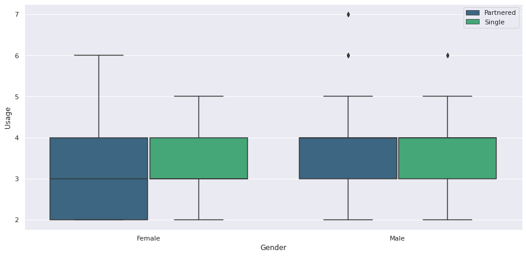

```python
plt.figure(figsize=(15,7))
sns.boxplot(CGFPdf["Gender"],CGFPdf["Usage"],hue=CGFPdf["MaritalStatus"],palette="viridis")
plt.legend(bbox_to_anchor=(1.00, 1))
plt.show()
```

OBSERVATIONS ABOVE:

- Usage for single females, single or partnered male is same it varies for females that have a partner.

#### **Gender vs. Income.**

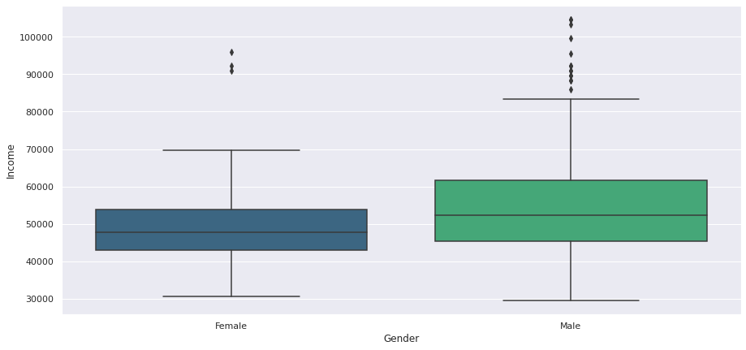

```python
plt.figure(figsize=(15,7))
sns.boxplot(CGFPdf["Gender"],CGFPdf["Income"],palette="viridis")
plt.show()
```

OBSERVATIONS ABOVE:

- There is a large disparity in income of both the genders, there are more males with higher income than females.

#### **Gender vs. Income vs. Marital Status.**

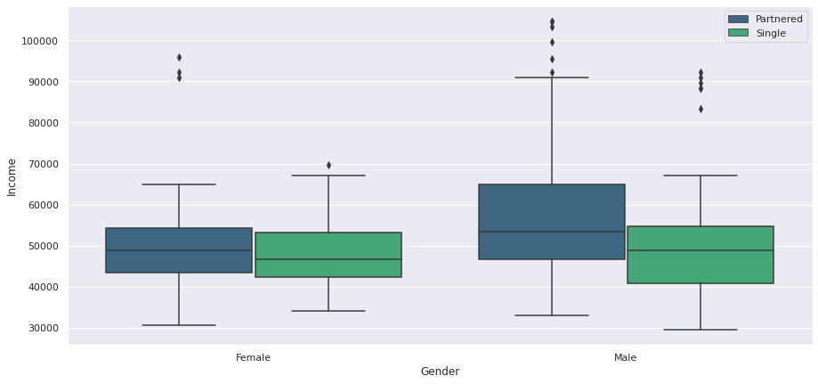

```python
plt.figure(figsize=(15,7))
sns.boxplot(CGFPdf["Gender"],CGFPdf["Income"],hue=CGFPdf["MaritalStatus"],palette="viridis")
plt.legend(bbox_to_anchor=(1.00, 1))
plt.show()
```

OBSERVATIONS ABOVE:

- Males with a partner have higher income, while the income for single and partnered females is almost compareable.

#### **Gender vs. Miles.**

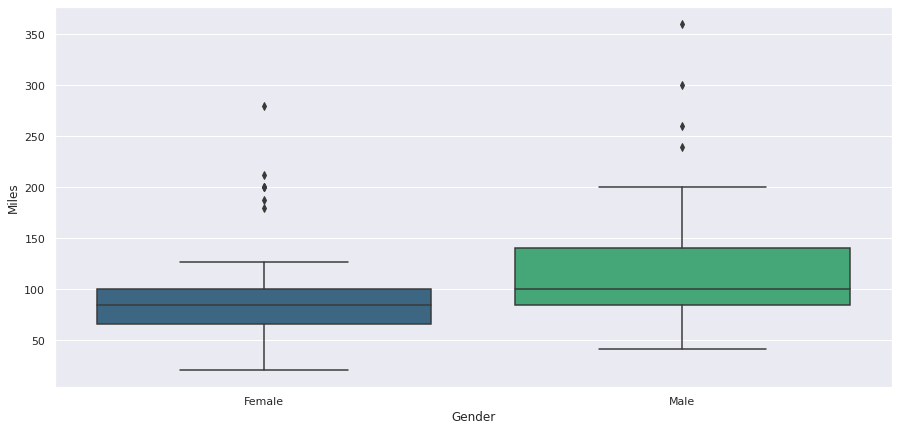

```python
plt.figure(figsize=(15,7))
sns.boxplot(CGFPdf["Gender"],CGFPdf["Miles"],palette="viridis")
plt.show()
```

OBSERVATIONS ABOVE:

- Males expect to run more miles than females.

#### **Gender vs. Miles vs. Marital Status.**

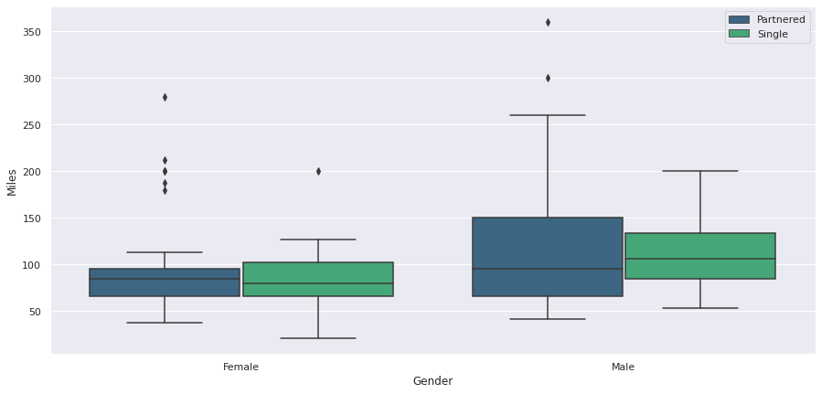

```python
plt.figure(figsize=(15,7))
sns.boxplot(CGFPdf["Gender"],CGFPdf["Miles"],hue=CGFPdf["MaritalStatus"],palette="viridis")
plt.legend(bbox_to_anchor=(1.00, 1))
plt.show()
```

OBSERVATIONS ABOVE:

- Single and Partnered male expect to run more miles, while not much difference can be noticed between Single or Partnered females.

#### **Gender vs. Miles vs. Education.**

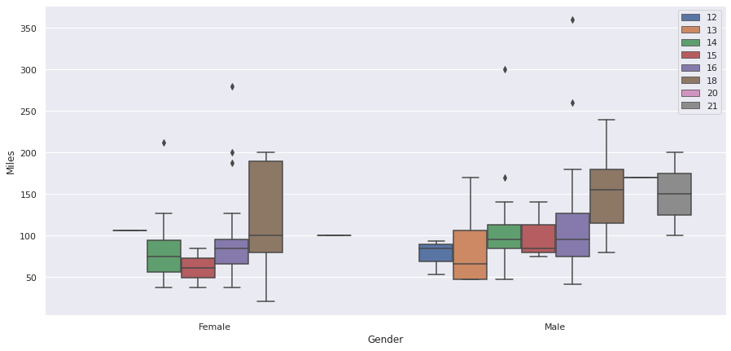

```python
plt.figure(figsize=(15,7))
sns.boxplot(CGFPdf["Gender"],CGFPdf["Miles"],hue=CGFPdf["Education"])
plt.legend(bbox_to_anchor=(1.00, 1))
plt.show()
```

OBSERVATIONS ABOVE:

- The expected miles to run increases as the education level increases, indicating that the more educated customers are more fitness aware.

#### **Age vs. Miles vs. Gender.**

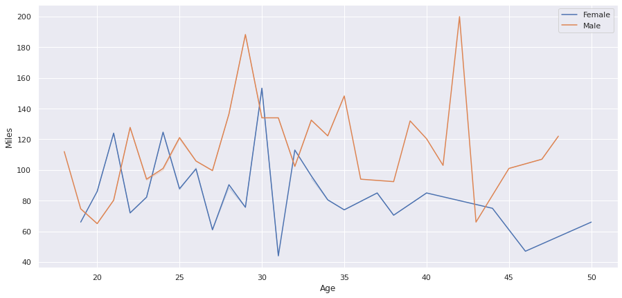

```python
plt.figure(figsize=(15,7))
sns.lineplot(CGFPdf["Age"],CGFPdf["Miles"],hue=CGFPdf["Gender"],ci=0)
plt.legend(bbox_to_anchor=(1.00, 1))
plt.show()
```

#### **Age vs. Miles vs. Marital Status.**

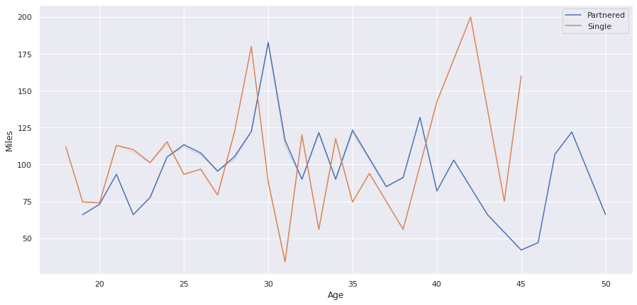

```python
plt.figure(figsize=(15,7))
sns.lineplot(CGFPdf["Age"],CGFPdf["Miles"],hue=CGFPdf["MaritalStatus"],ci=0)
plt.legend(bbox_to_anchor=(1.00, 1))
plt.show()
```

OBSERVATIONS ABOVE:

- The trend is mostly similar across younger years for a single or a customer with a partner, however after 40 years singles tend to work more on their fitness.

#### **Age vs. Income vs. Product.**

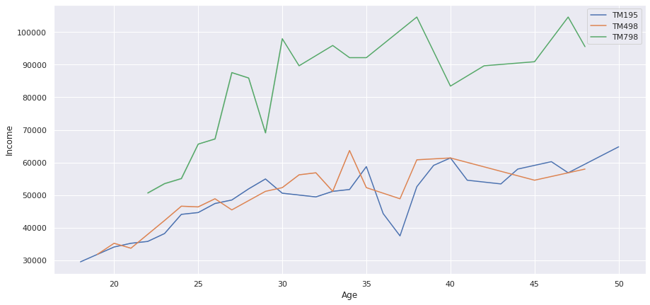

```python
plt.figure(figsize=(15,7))
sns.lineplot(CGFPdf["Age"],CGFPdf["Income"],hue=CGFPdf["Product"],ci=0)
plt.legend(bbox_to_anchor=(1.00, 1))
plt.show()
```

#### **Income vs. Miles vs. Education.**

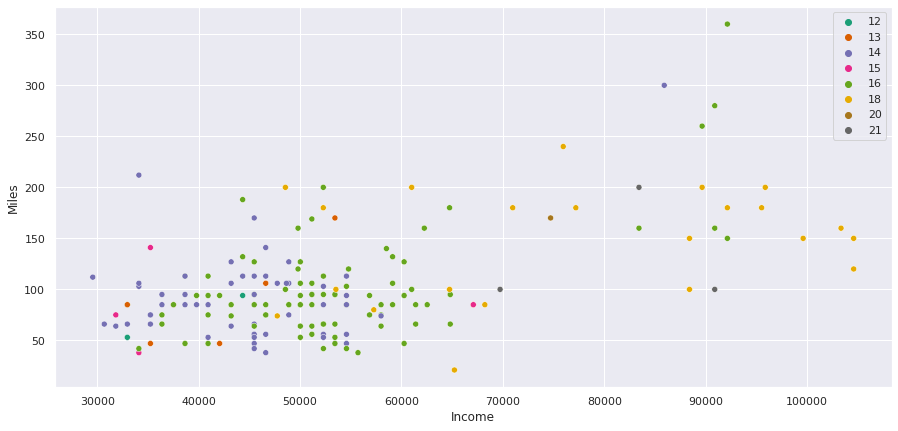

```python
plt.figure(figsize=(15,7))
sns.scatterplot(CGFPdf["Income"],CGFPdf["Miles"],hue=CGFPdf["Education"],ci=0.,palette="Dark2")
plt.legend(bbox_to_anchor=(1.00, 1))
plt.show()
```

#### **Income vs. Miles vs. Product.**

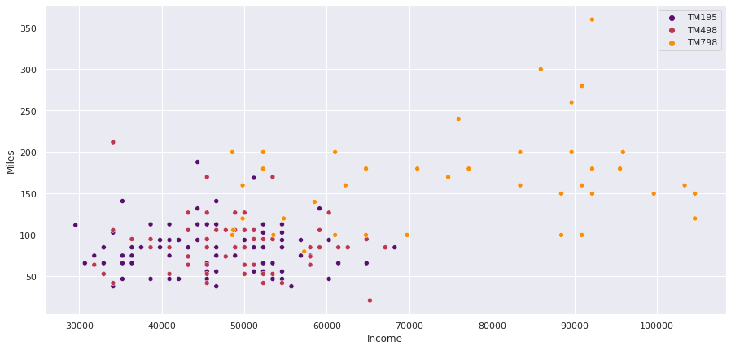

```python
plt.figure(figsize=(15,7))
sns.scatterplot(CGFPdf["Income"],CGFPdf["Miles"],hue=CGFPdf["Product"],ci=0,palette="inferno")
plt.legend(bbox_to_anchor=(1.00, 1))
plt.show()
```

OBSERVATIONS ABOVE:

- Customers having an income of more than 70k tend to buy TM798 and run more miles.

## Conclusion

### Key insights

#### **TM195:**

- An affordable and general-purpose treadmill that can be used for a wide range of users.
- It can be considered as an entry-level product generally targeted for first-time fitness enthusiasts or college-going population.
- Customers with light to moderate usage 3 to 4 times a week go for this product.

</br>

#### **TM495:**

- An affordable product like the TM195 with more features and probably has a high price than TM195.
- The product also generally targets the same age group as the TM195 but has users of slightly higher income.
- The product is used generally 3 times per week.

</br>

</br>

## Business Recommendations.

**No pricing nor costs of the 3 treadmill models are provided in this data set. The following narrative can only make educate assumptions around these.**

- The company has an affordable product in its portfolio that brings in the bulk of the volume of its sales, which is the TM195. The TM798 is their flagship product that brings in the profits for the company.
- The company needs to engage in more marketing to convey that product TM798 is suitable for both the genders and try to lure the younger age group into buying their flagship product. Currently, it seems TM798 is marketed as an exclusive product for the males making more money as there is a large disparity in income for both genders.
- Years of education are proportionate to income, and so customers with higher education can be recommended an expensive model (TM798).
- Females above 30 years can be recommended the lower end products (TM195 and TM498) since they wish to run a fewer number of miles and therefore the usage of the product won't be higher.
- Partnered Females can be recommended all types of products (low end to high end) since their usage varies from 2 days per week to 6 days per week.
- Singles above 40 years can be recommended the higher end product (TM798) since they wish to run more miles and therefore the usage would be higher.
- Partnered males have a higher income and also expect to run more miles hence the higher end product TM798 would be a good recommendation for them.

## Extra Analysis

### A Baseline Linear Regression Model.

```python
# Predicts number of miles run based on usage and fitness level
# Import and load sklearn

from sklearn import linear_model

# Create the linear regression object
CGFPregr = linear_model.LinearRegression()

y = CGFPdf['Miles']
x = CGFPdf[['Usage','Fitness']]

# Animate the model

CGFPregr.fit(x,y)
```

```
LinearRegression()
```

```python
# Calculate the linear regression coefficient

CGFPregr.coef_
```

```
array([20.21486334, 27.20649954])
```

```python
# Calculate the y-intercept

CGFPregr.intercept_
```

```
-56.74288178464862
```

#### **Miles Predicted**

A predictive linear equation equation has been derived as follows:

Miles Predicted = -56.74 + 20.21 * [Usage] + 27.20 [Fitness]